# Philippines, PHILB: SAP Evaluation

## Evaluation Data Collected

**ID** (string)

ID of the OTU sequence. Only those sequences that were assigned to some taxonomic rank included. Of interest is what factors lead to a higher taxonomic ranking than species being chosen. The assumption is that those unable to be assigned at all are legitimately difficult to assign and may be noisy sequences or unrepresented species.

**has species level** (boolean)

Whether or not the OTU was assigned at the species level. If False, the assignment was at a higher rank such as genus or phylum.

**species count** (integer)

Number of species (homologous sequences) included in the best phylogenetic tree. This is equivalent to the number of tree branches.

**branch leaf count** (integer)

The number of times that a genus branches, resulting in leaves that come from the same node. It is expected that homologues would be in the same genus. The case where multiple high probable sequences from the same genus occur could represent an instance where it was legitimatly difficult to choose the correct species.

**interior leaf count** (integer)

The number of times that branches occur at interior nodes, such as at the phylum or family ranks. This means that significant homologue sequences occur in different genus. Since genetic regions should differ more among sequences of different branches in the phylogenetic tree, this may be indicative of mislabelled sequences in the reference database.

**species probability max** (decimal)

**species probability min** (decimal)

The lowest posterior probability for a species.

**homologues to analyze count** (integer)

A homologue is analyzed for the evaluation when it has an identity score >= 0.90 with the query sequences. Analyses means to see if the homologue appears to be mislabelled in the reference database.

**homologues suspicious records count** (integer)

The number of analyzed homologues whose genus differed from the most frequent genus in that homologues blast results. Only those results whose identity with the blasted homologue was >= 0.90 are included.

**has homologues suspicious records** (boolean)

Whether or not suspicious records exist. This is true when “homologues suspicious records count” > 0.

## Data overview

| ID | SpeciesLevel | SpeciesCount | BranchLeafCount | BranchInteriorCount | SpeciesProbMax | SpeciesProbMin | HomologuesToAnalyzeCount | HomologuesSuspiciousRecordsCount | HasHomologuesSuspiciousRecords | HomologueCount | DatabaseNotExhausted |
| --- | --- | --- | --- | --- | --- | --- | --- | --- | --- | --- | --- |
| PHILA153-13\|Pomadasys argenteus\|PI-0153\|PI-0153\|USNM 403153\|\|Haemulidae\|Pomadasys\|Pomadasys argenteus | TRUE | 1 | 0 | 1 | 1.000 | 1.000 | 2 | 0 | FALSE | 1 | FALSE |
| PHILA599-13\|Stolephorus waitei\|RP125\|RP125\|USNM 408925\|\|Engraulidae\|Stolephorus\|Stolephorus waitei | TRUE | 1 | 0 | 1 | 0.999 | 0.999 | 0 | 0 | FALSE | 1 | FALSE |
| PHILA142-13\|Gerres erythrourus\|PI-0142\|PI-0142\|USNM 403142\|\|Gerreidae\|Gerres\|Gerres erythrourus | TRUE | 1 | 0 | 1 | 1.000 | 1.000 | 1 | 0 | FALSE | 1 | FALSE |
| PHILA350-13\|Hemigymnus fasciatus\|PI-0347\|PI-0347\|USNM 403347\|\|Labridae\|Hemigymnus\|Hemigymnus fasciatus | TRUE | 2 | 1 | 1 | 0.994 | 0.003 | 2 | 0 | FALSE | 1 | FALSE |
| PHILA200-13\|Pelates quadrilineatus\|PI-0202\|PI-0202\|USNM 403202\|\|Terapontidae\|Pelates\|Pelates quadrilineatus | TRUE | 3 | 0 | 3 | 0.433 | 0.039 | 3 | 2 | TRUE | 1 | FALSE |
| PHILA138-13\|Pterocaesio tessellata\|PI-0138\|PI-0138\|USNM 403138\|\|Caesionidae\|Pterocaesio\|Pterocaesio tessellata | TRUE | 1 | 0 | 1 | 1.000 | 1.000 | 13 | 9 | TRUE | 1 | FALSE |

```
##                                                                                                                     ID
##  PHILA064-13|Epinephelus ongus|PI-0064|PI-0064|USNM 403064||Serranidae|Epinephelus|Epinephelus ongus                 :1
##  PHILA136-13|Pristipomoides typus|PI-0136|PI-0136|USNM 403136||Lutjanidae|Pristipomoides|Pristipomoides typus        :1
##  PHILA138-13|Pterocaesio tessellata|PI-0138|PI-0138|USNM 403138||Caesionidae|Pterocaesio|Pterocaesio tessellata      :1
##  PHILA142-13|Gerres erythrourus|PI-0142|PI-0142|USNM 403142||Gerreidae|Gerres|Gerres erythrourus                     :1
##  PHILA145-13|Auxis rochei|PI-0145|PI-0145|USNM 403145||Scombridae|Auxis|Auxis rochei                                 :1
##  PHILA163-13|Plectropomus oligacanthus|PI-0163|PI-0163|USNM 403163||Serranidae|Plectropomus|Plectropomus oligacanthus:1
##  (Other)                                                                                                             :5
##  SpeciesLevel    SpeciesCount   BranchLeafCount  BranchInteriorCount
##  Mode:logical   Min.   :1.000   Min.   :0.0000   Min.   :1.000
##  TRUE:11        1st Qu.:1.000   1st Qu.:0.0000   1st Qu.:1.000
##                 Median :1.000   Median :0.0000   Median :1.000
##                 Mean   :1.727   Mean   :0.5455   Mean   :1.182
##                 3rd Qu.:2.000   3rd Qu.:1.0000   3rd Qu.:1.000
##                 Max.   :4.000   Max.   :3.0000   Max.   :3.000
##
##  SpeciesProbMax   SpeciesProbMin   HomologuesToAnalyzeCount
##  Min.   :0.1730   Min.   :0.0030   Min.   : 0.000
##  1st Qu.:0.6055   1st Qu.:0.1560   1st Qu.: 1.500
##  Median :0.9990   Median :0.9990   Median : 3.000
##  Mean   :0.8009   Mean   :0.5978   Mean   : 5.727
##  3rd Qu.:1.0000   3rd Qu.:1.0000   3rd Qu.: 6.500
##  Max.   :1.0000   Max.   :1.0000   Max.   :24.000
##
##  HomologuesSuspiciousRecordsCount HasHomologuesSuspiciousRecords
##  Min.   : 0.000                   Mode :logical
##  1st Qu.: 0.000                   FALSE:5
##  Median : 1.000                   TRUE :6
##  Mean   : 2.545
##  3rd Qu.: 2.000
##  Max.   :13.000
##
##  HomologueCount DatabaseNotExhausted
##  Min.   :1      Mode :logical
##  1st Qu.:1      FALSE:11
##  Median :1
##  Mean   :1
##  3rd Qu.:1
##  Max.   :1
##
```

### Species Assignment

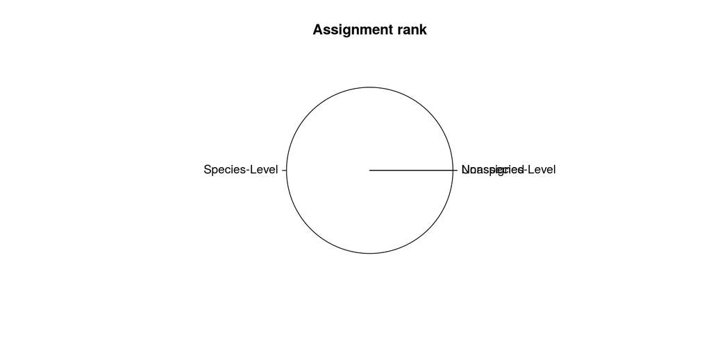

### Compare posterior probabilties

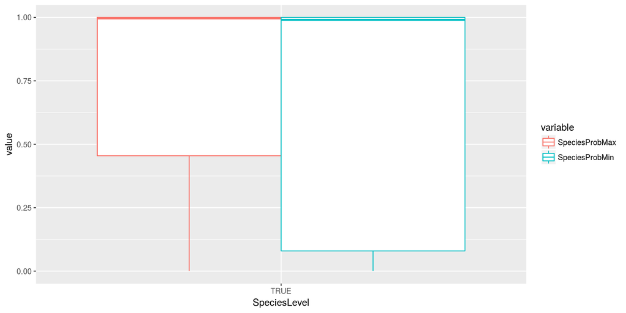

### Compare tree topology

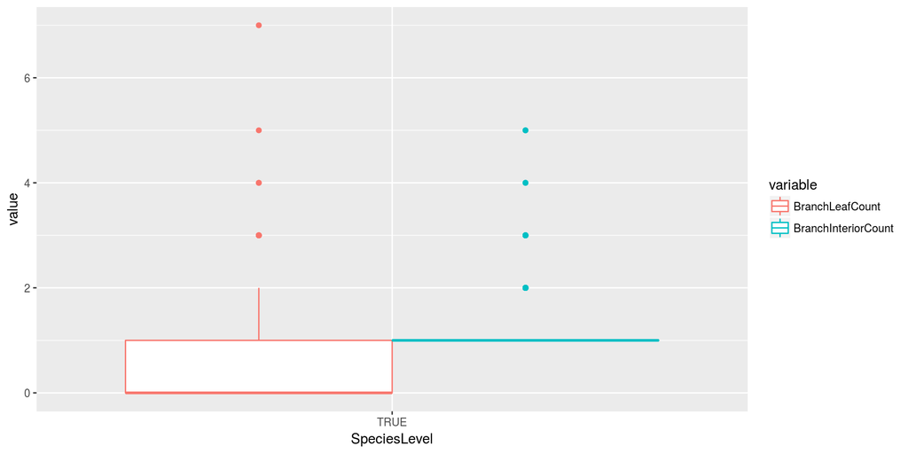

Interior node branches in tree topology suggest outliers which affect the sampled trees and thus the propabilities. Leaf-level branching (where leaves extend from same parent) indicates the legit cases where the exact species in a genus is unclear. Based on the manually observed situations, it appears that when a sequence whose lineage branches higher in the tree has very low probability but affects the probability of the more common group by appearing in a proportion of the sampled trees.

### Compare homologues

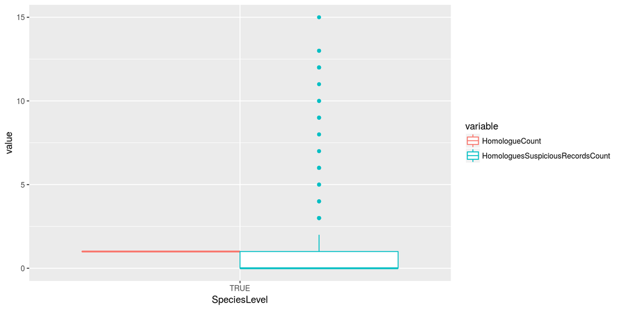

### Database not Exhausted

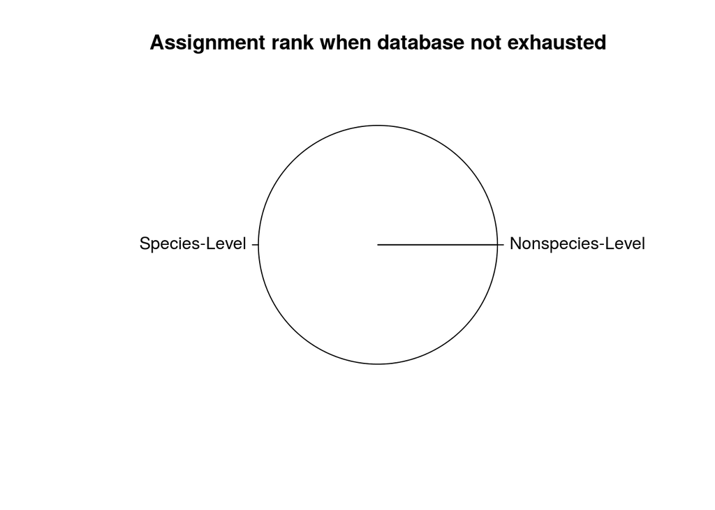

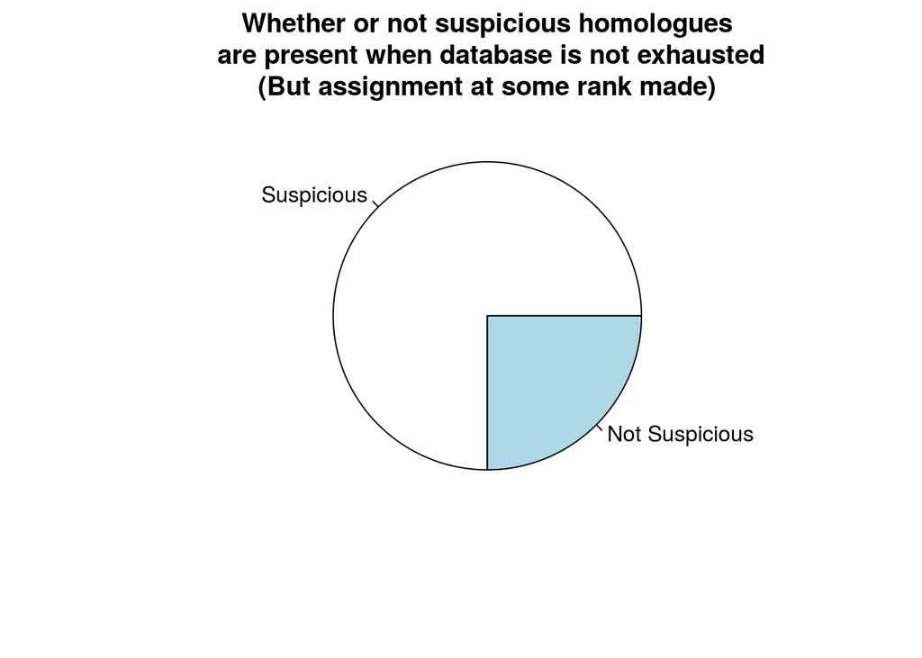

If that database is not exhasuted, it is almost certainly not going to make a species-level identification. However, the database might not be exhausted even when the reference database appears to be correct. It remains to be understood why seemingly legitimate homologues are compiled from widely unrelated species.

## Data Mining

### Classification (J48)

By manually observing trees and analysing the box plots, it was possible to see that certain factors were indicative of the inability to make a species-level assignment.

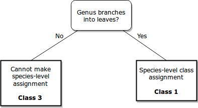

**Tree Accuracy**

**Stratified cross-validation**

- Correctly Classified Instances: 210 (79.8479%)
- Incorrectly Classified Instances: 53 (20.1521%)
- Kappa statistic: 0.6023
- Mean absolute error: 0.2982
- Root mean squared error: 0.3889
- Relative absolute error: 60.8359%
- Root relative squared error: 78.5655%
- Total Number of Instances: 263

**Detailed Accuracy By Class**

| TP Rate | FP Rate | Precision | Recall | F-Measure | ROC Area | Class |
| --- | --- | --- | --- | --- | --- | --- |
| 0.903 | 0.280 | 0.708 | 0.903 | 0.794 | 0.807 | True |
| 0.720 | 0.097 | 0.908 | 0.720 | 0.803 | 0.807 | False |

**Confusion Matrix**

| a | b |  |
| --- | --- | --- |
| 102 | 11 | a = True |
| 42 | 108 | b = False |

### Conclusions

- An error-free database would prevent the case of mislabelled records preventing a species-level assignment.
- Where BLAST simply report hits and users are left either accepting the top hit or devising a way to choose one, SAP decides when the species cannot be reliably determined and chooses a higher level where it is sufficiently confident.
- The wealth of data stored by SAP makes it possible to understand how assignments were made. Even when a higher-than-species rank is chosen, can still get statistics on the considered species. This is much easier to evaluate than Ecotag where it was difficult to know why it reported so many high-level ranks.
- SAP does not want to be biased toward a particular overrepresented species in a database, so it prioritizes broad species selection for homologues. This makes SAP particularly susceptable to outlier sequences.
- The credability of these sequences is not addressed in this document. A companion document compares the SAP results to those from other taxonomic assignment methods as well as to a set of known species that should appear in the results.
- At a 0.97 Blast identity score for considering suspicious homologues, fewer suspicious homologues were found. While 32 cases of single-suspicious and 18 two-suspicious homologues for an OTU were still present, the use of the suspicious homologues occurance disappeared from the decision tree. That said, the tree was ~ 3% less accurate than when using a 0.90 cutoff. It seems that the existance of species of other genus in the homologues can keep SAP from a species-level assignment even though it is biologically reasonable for species of different genus to have a 0.90 similarity.